# 逻辑回归：留学申请

韩司仪 20210980106@fudan.edu.cn

3/28/2022

```r
# 加载所需要的包
library(ggplot2)
library(reshape)
library(dplyr)
# 注释快捷键，ctrl/command+shift+c
# library(gdtools)
# ?sys_fonts # 列出系统字体。
# View(sys_fonts())
# Win10: SimHei、STXihei

## 设置绘图主题
# ggplot() + theme_bw()
# ggplot() + plot_theme_pie
# ggplot() + plot_theme

# plot_theme <- theme(xxxxxxxxxxx)

# 饼图绘制主题
theme(panel.background = element_rect(fill = rgb(255, 255, 255, maxColorValue = 255)),
      plot.background = element_rect(rgb(255, 255, 255, maxColorValue = 255)),
      axis.text = element_text(color = rgb(236, 241, 249, maxColorValue = 255)),
      panel.grid.major = element_line(color = rgb(236, 241, 249, maxColorValue = 255)),
      panel.grid.minor = element_line(color = rgb(236, 241, 249, maxColorValue = 255)),
      plot.title = element_text(family = "Hei", face = "bold", size = 14),
      legend.title = element_text(family = "Hei", face = "bold",size = 12),
      legend.text = element_text(family = "Hei",size = 11)) -> plot_theme_pie # 饼图绘制主题
## 设置绘图主题
theme(panel.background = element_rect(fill = rgb(255, 255, 255, maxColorValue = 255)),
      plot.background = element_rect(rgb(255, 255, 255, maxColorValue = 255)),
      axis.text = element_text(size = 12,family = "Hei"),
      axis.text.x = element_text(size = 12, family = "Hei", face = "bold") ,
      axis.text.y = element_text(size = 12, family = "Hei", face = "bold") ,
      axis.ticks = element_line(color = rgb(236, 241, 249, maxColorValue = 255)),
      axis.title = element_text(size = 13, family = "Hei"),
      panel.grid.major = element_line(size = 1),
      panel.grid.minor = element_line(color = rgb(236, 241, 249, maxColorValue = 255)),
      plot.title = element_text(family = "Hei", face = "bold", size = 14),
      legend.title = element_text(family = "Hei", face = "bold",size = 12),
      legend.text = element_text(family = "Hei",size = 11)) -> plot_theme   # 其他图形绘制主题
```

```r
## 读入数据
# tips: option/alt+减号可以打出 <-
#       ctrl/command + enter可以运行光标所在行的代码/选定的代码段
#       R中 true和false可以用TRUE/FALSE or T/F两种方式表示
descriptive <- read.csv("Data_Cleaning.csv", header = T, stringsAsFactors = F) # 读取原始数据

# tips: ctrl+shift+m可以打出管道函数 %>%
#       管道函数的本质是将 %>% 前代码输出的结果，直接导入为 %>% 后函数第一个参数的值
# paste("a","b")
# "a" %>% paste("b")

# descriptive %>% View() # 查看数据情况
descriptive <- descriptive[order(descriptive$index_origin),]  # 将数据按照变量index_origin（原始编号）排序

## 调整变量类型
descriptive$offertype[descriptive$offertype %in% c("AD小奖", "Offer", "AD无奖")] <- "Admitted"    # 不考虑奖学金，均归入“Admitted“（录取）

descriptive$offertype[descriptive$offertype == "Rej"] <- "Rejected"
descriptive <- descriptive[ - which(descriptive$offertype == ""),]   # 删去缺失录取结果的样本
```

## 3. 描述分析

### 3.1 因变量

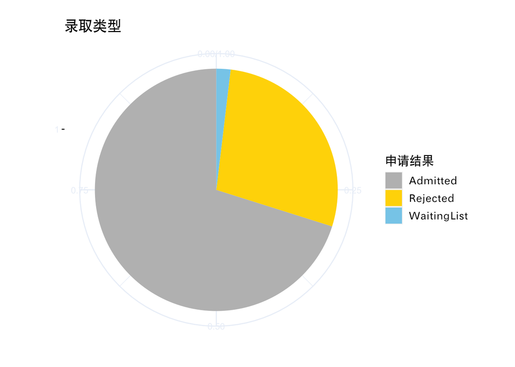

```r
piechart1 <- ggplot(descriptive) +
  geom_bar(aes(x = factor("1"), fill = factor(offertype)), position = "fill", width = 1) +
  # position参数，有stack、fill、dodge
  scale_fill_manual("申请结果", values = c("grey", "gold", "skyblue")) +
  coord_polar(theta = "y") +
  labs(x = "", y = "", title = "\n录取类型") +
  plot_theme_pie

piechart1
```

### 3.2 自变量

#### 申请学校

我们先来看热门的申请学校（college_apply）。由于数据存在错误，我们需要对申请学校这一变量进行简单修正：将学校名”Texas A”、“M University”替换”Texas A&M University”，将”Washington University in St”、” Louis”替换为”Washington University in St.Louis”。随后，为了统一申请学校名称，我们要将学校缩写替换为全称，得到的新变量College_apply_new 并入原数据（注意：不考虑缩写字母的大小写差异，需要借助文件美国大学缩写汇总.txt）。根据统一后的学校名称，找出申请人数最多的10所热门学校。

```r
## 修正数据
# descriptive$college_apply %in% c("Texas A", "M University")得到一个bool mask
descriptive$college_apply[descriptive$college_apply %in% c("Texas A", "M University")] <- "Texas A&M University"
descriptive$college_apply[descriptive$college_apply %in% c("Washington University in St", " Louis")] <- "Washington University in St. Louis"

## 统一学校名称
SuoXie <- read.table("美国大学缩写汇总.txt", header = T)  # 读入常见的美国大学缩写汇总
# SuoXie %>% View()

college_apply_new <- NULL                                 # 设置初始值
college_low <- tolower(descriptive$college_apply)         # 不考虑大小写差异（下同）
suoxie_low <- tolower(SuoXie$ysuoxie)

# dim(descriptive)
# nrow(descriptive)
# ncol(descriptive)

for(i in 1:dim(descriptive)[1]){                          # 统一全称和缩写
  if (college_low[i] %in% suoxie_low) {
    college_apply_new[i] <- as.character(SuoXie$yquancheng[suoxie_low %in% college_low[i]])
  } else {
    college_apply_new[i] <- descriptive$college_apply[i]
  }
}
descriptive$College_apply_new <- college_apply_new        # 统一学校名称后的新变量

## 找出10大热门学

(top10_college_apply <- names(sort(table(descriptive$College_apply_new), decreasing = T)[c(1:10)]))
```

```
##  [1] "University of California"
##  [2] "Carnegie Mellon University"
##  [3] "University of Southern California"
##  [4] "Columbia University"
##  [5] "University of Pennsylvania"
##  [6] "Northeastern University"
##  [7] "University of Illinois at Urbana-Champaign"
##  [8] "University of Michigan"
##  [9] "Cornell University"
## [10] "Texas A&M University"
```

找到10所热门学校后，下一步探究这些学校的录取情况。为简化后续分析，删掉所有录取结果为 WaitingList 的样本，只保留15908条数据。

绘制录取结果的堆积条形图，此处使用学校名称缩写以便图形展示。

[figure not shown]

```r
## 为简化后续分析，删掉录取结果为 WaitingList 的样本
descriptive <- descriptive[-which(descriptive$offertype == "WaitingList"),]
# 例子
# example <- data.frame(a = 1:5, b = 6:10, c = 11:15)
# example[-c(2, 3), -2]
# descriptive <- descriptive[descriptive$offertype != "WaitingList",]

## 统计热门学校录取情况
descriptive_top10 <- descriptive[descriptive$College_apply_new %in% top10_college_apply, ]
Top10_college_apply <- as.data.frame(table(descriptive_top10$College_apply_new,
                                           descriptive_top10$offertype))
colnames(Top10_college_apply) <- c("college", "申请结果", "number")   # 修改列名

## 缩写学校名称，以便图形展示
Top10_college_apply$college <- factor(Top10_college_apply$college,
                                      levels = top10_college_apply,
                                      labels = c("CMU", "UC", "USC", "Columbia", "UPenn"
                                              , "UIUC", "NEU", "UMich", "Cornell", "TAMU"))


## 热门学校申请人数条形图
(barplot1 <- ggplot(Top10_college_apply) +
    geom_bar(aes(x = college, y = number, fill = 申请结果),
             show.legend = T, stat = 'identity', position = 'stack', ) +
    labs(x = "", y = "\n申请人数", title = "\nTOP10 热门学校申请人数") +
    scale_fill_manual("申请结果", values = c("grey", "gold")) +    # 按照申请结果填色
    theme(axis.text.x = element_text(angle = 30, hjust = 0.5)) +
    plot_theme)
```

#### 申请专业

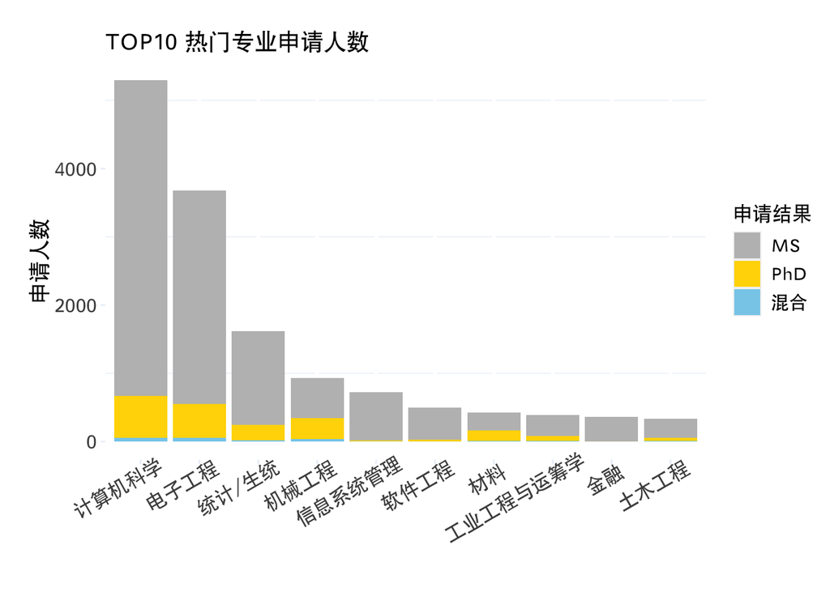

```r
## 统计热门专业申请情况
major_ap_top <- as.data.frame(sort(table(descriptive$major_apply),
                                   decreasing = T)[c(1:7, 9:11)])  # 统计申请专业
descriptive_top10_major <- descriptive[descriptive$major_apply %in% major_ap_top$Var1, ]
Top10_major_apply <- as.data.frame(table(descriptive_top10_major$major_apply,
                                         descriptive_top10_major$type))
colnames(Top10_major_apply) <- c("major", "type", "number")   # 修改列名

## 缩写学校名称，以便图形展示
Top10_major_apply$major <- factor(Top10_major_apply$major,
                                      levels = major_ap_top$Var1,
                                      labels = c("计算机科学", "电子工程", "统计/生统", "机械工程", "信息系统管理", "软件工程","材料", "工业工程与运筹学", "金融", "土木工程"))


## 热门专业申请人数条形图
(barplot6 <- ggplot(Top10_major_apply, aes(x = major, y = number, fill = type)) +
    geom_bar(show.legend = T, stat = 'identity',position = 'stack', ) +
    labs(x = "", y = "\n申请人数", title = "\nTOP10 热门专业申请人数") +
    scale_fill_manual("申请结果", values = c("grey", "gold", "skyblue")) +    # 按照申请结果填色
    theme(axis.text.x = element_text(angle = 30, hjust = 0.8)) +
    plot_theme)
```

#### 申请成绩

- GPA

GPA（标准化考试成绩）是申请的关键之一。用变量gpa除以分制变量gpa_measure，再乘以4.0，可以将GPA标准化为四分制，得到新变量Standardgap并入原数据。考虑到不同排名的学校对学生成绩的要求差异，对申请学校进行排名划分。读入“QS大学排名前百（美国）.txt”，数据集前19所学校是世界前五十名的美国名校，据此将所有申请学校划分为”Top50”和”Others”两类，得到因子型的新变量CollegeRankTop50并入原数据。

接着，考查学业成绩Standardgap和学校排名CollegeRankTop50对录取结果的影响。绘制成绩与申请结果箱线图，并谈谈你的发现。只画出Standardgap>2.0的样本。

最后，将成绩划分为”<=3.4”, “3.4-3.55”, “3.55-3.7”, “>3.7”四类，得到新变量gpa_dis并入原数据。

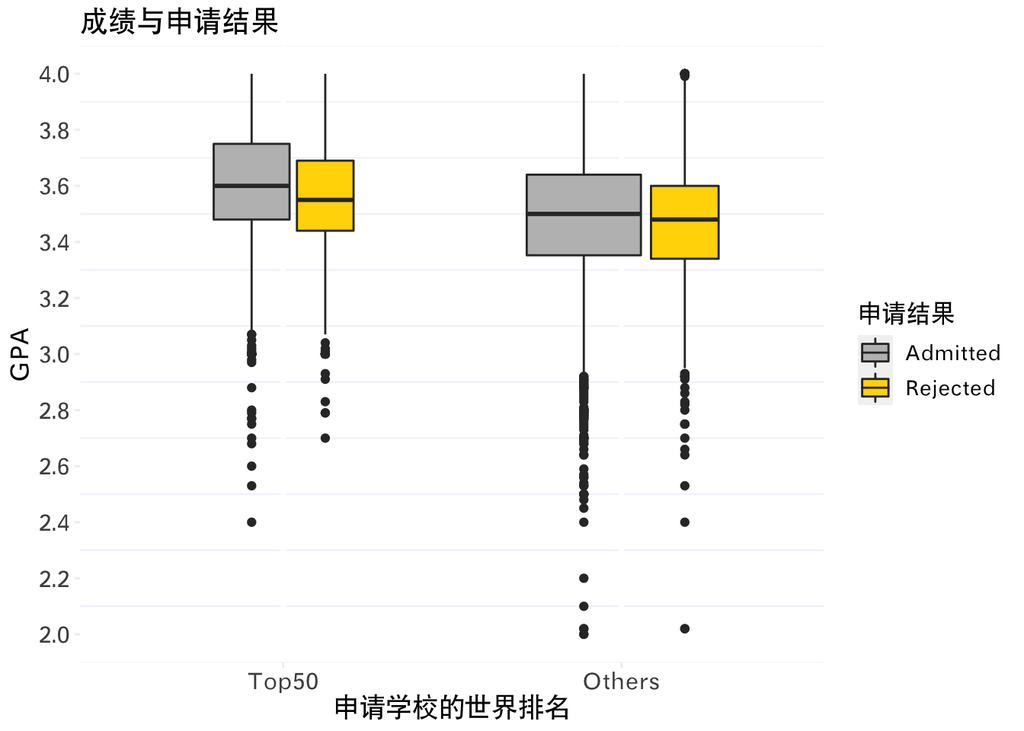

```r
## 按学校名称匹配大学排名
universities <- read.table("QS大学排名前百（美国）.txt",header = F, sep="\n")$V1     # 读入QS世界大学排名
top50university <- NULL   # 变量初始化
for(i in 1:dim(descriptive)[1]){
  top50university[i] <- descriptive$College_apply_new[i] %in% universities[1:19]  # 共19所美国名校进入世界前五十名
}

## 整理变量
collegerank <- rep("Others",dim(descriptive)[1])
collegerank[top50university] <- "Top50"                      # 大学排名前50
descriptive$CollegeRankTop50 <- collegerank                  # 并入原数据

## gpa标准化
descriptive$Standardgap <- (descriptive$gpa/descriptive$gpa_measure)*4      # 将gpa统一整理为4分制
gpa_offertype <- descriptive[, c("Standardgap", "offertype", "CollegeRankTop50")]
gpa_offertype$offertype <- factor(gpa_offertype$offertype, levels = c("Admitted", "Rejected"),
                                 # labels = c("录取","被拒"),
                                 labels = c("Admitted", "Rejected"))                 #  调整因子水平
gpa_offertype$CollegeRankTop50 <- factor(gpa_offertype$CollegeRankTop50, levels = c("Top50","Others"))



## 画图
boxplot1 <- ggplot(gpa_offertype, aes(x = factor(CollegeRankTop50), y = Standardgap, fill = factor(offertype))) +
  geom_boxplot(show.legend = T, varwidth = T) +
  scale_fill_manual("申请结果", values = c("grey", "gold")) +    # 按照申请结果填色
  scale_y_continuous(limits = c(2, 4),breaks = seq(2, 4, by = 0.2))+     # 不考虑gpa<2.0的样本
  labs(x = "申请学校的世界排名", y = "GPA", title = "成绩与申请结果") +
  plot_theme
boxplot1
```

结论：申请 Top50 学校时，录取的学生平均GPA（中位数）较高。申请其他学校时，GPA差异不明显。而从波动程度来看，无论是申请Top50还是其他学校，录取同学的GPA的差异都比未录取的GPA差异大，说明高GPA不一定是录取的必要因素。

```r
## 成绩分段
descriptive$gpa_dis <- cut(descriptive$Standardgap, breaks = c(0, 3.4, 3.55, 3.7, Inf),
                           labels = c("<=3.4", "3.4~3.55", "3.55~3.7", ">3.7"))
```

- TOFEL

托福成绩也是申请时至关重要的一环。将变量toefl转化为数值变量，随后划分为”<=98”, “98-102”, “102-106”,“>106”四个分数段，得到因子型的新变量toefl_dis并入数据。计算不同排名的学校在各分数段的录取率，绘制复式条形图。注意标注出录取率百分数，并添加一条平均录取率作为参考线。从图中你能得到什么结论？

```r
## 整理托福成绩
descriptive$toefl <- as.numeric(descriptive$toefl)    # 将托福成绩信息变为数值型
```

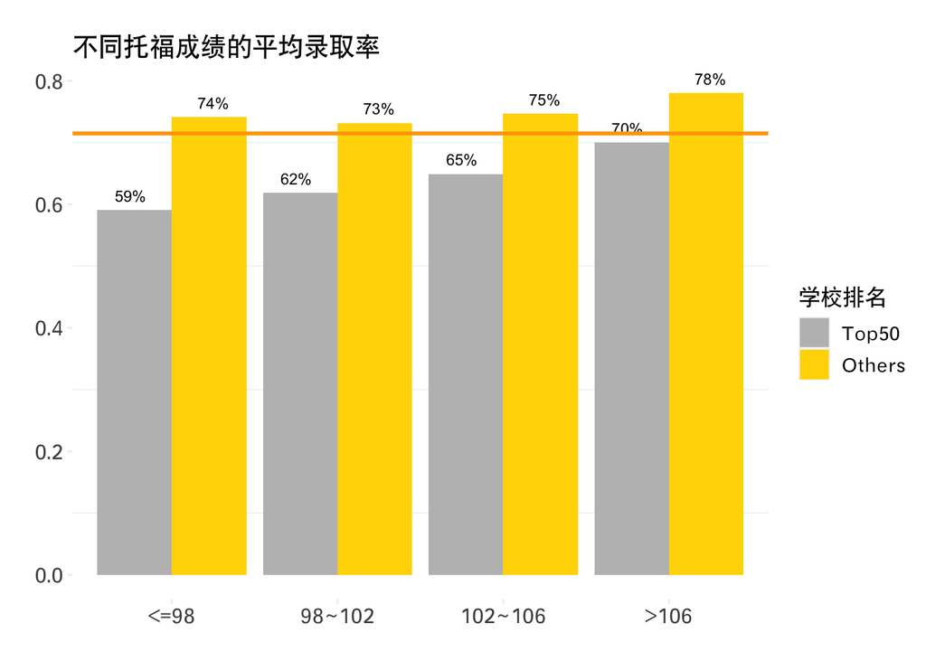

```r
descriptive$toefl_dis <- cut(descriptive$toefl, breaks = c(0, 98, 102, 106, Inf),
                             labels = c("<=98", "98~102", "102~106", ">106"))

## 计算录取率
ifadmitted <- ifelse(descriptive$offertype == "Admitted",1,0)
admittedPct <- aggregate(ifadmitted, list(descriptive$toefl_dis, descriptive$CollegeRankTop50), mean)
colnames(admittedPct) <- c("TOEFL","学校排名","admittedpct")
admittedPct$学校排名 <- factor(admittedPct$学校排名,levels = c("Top50","Others"))

### 画图
(barplot2 <- ggplot(admittedPct, aes(TOEFL, admittedpct, fill = 学校排名)) +
  geom_bar(stat='identity', position='dodge') +
  scale_fill_manual("学校排名", values = c("grey", "gold")) +    # 按照申请结果填色
  labs(x="", y="", title="\n不同托福成绩的平均录取率") +
  # geom_text(label = paste(round(admittedPct[order(admittedPct$TOEFL), 3], 2)*100, "%", sep=''),
  geom_text(label = paste(round(admittedPct$admittedpct, 2)*100, "%", sep=''),
            colour = "black", position = position_dodge(1), size = 3, vjust = - 0.8)  +
  geom_hline(aes(yintercept = mean(ifadmitted)), col = "orange", lwd = 1)+
  geom_text(label = paste(round(mean(ifadmitted), 2)*100, "%", sep=''),
            colour = "orange",x = 5.4, y = 0.7, size = 5.7, vjust =  - 0.5) +
  plot_theme)
```

- GRE

```r
## 整理GRE
descriptive$gre_total <- as.numeric(descriptive$gre_total)    # 将托福成绩信息变为数值型
```

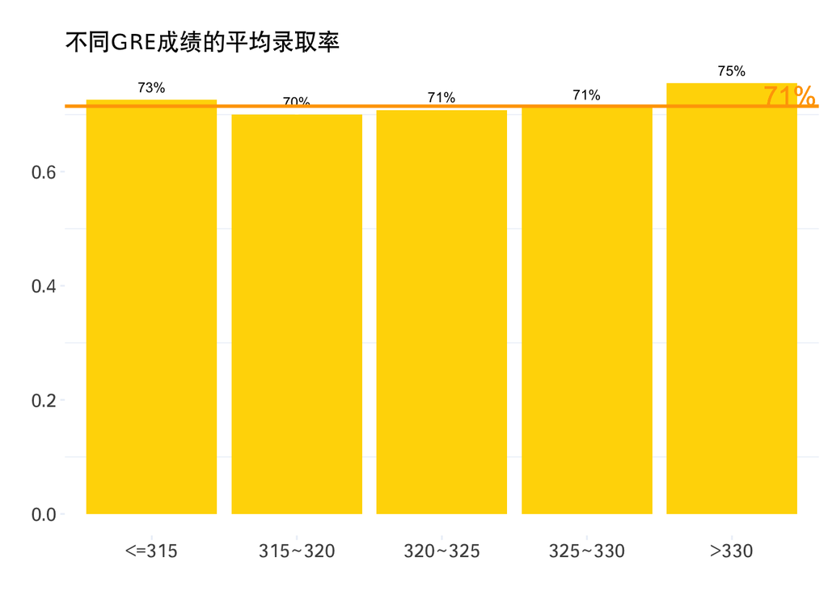

```r
# cut函数左开右闭
descriptive$gre_dis <- cut(descriptive$gre_total, breaks = c(0, 315, 320, 325, 330, Inf),
                             labels = c("<=315", "315~320", "320~325", "325~330", ">330"))

## 计算录取率
ifadmitted <- ifelse(descriptive$offertype == "Admitted", 1, 0)
admittedPct <- aggregate(ifadmitted, list(descriptive$gre_dis), mean)
colnames(admittedPct) <- c("GRE","admittedpct")

### 画图
(barplot7 <- ggplot(admittedPct, aes(GRE, admittedpct)) +
  geom_bar(stat='identity',position='dodge', fill = "gold") +
  # scale_fill_manual("学校排名", values = c("grey", "gold")) +    # 按照申请结果填色
  labs(x="", y="", title="\n不同GRE成绩的平均录取率") +
  geom_text(label = paste(round(admittedPct$admittedpct, 2)*100, "%", sep=''),
            colour = "black", position = position_dodge(1), size = 3, vjust = - 0.8)  +
  geom_hline(aes(yintercept = mean(ifadmitted)), col = "orange", lwd = 1)+
  geom_text(label = paste(round(mean(ifadmitted), 2)*100, "%", sep=''),
            colour = "orange",x = 5.4, y = 0.7, size = 5.7, vjust =  - 0.5) +
  plot_theme)
```

#### 申请学位类型

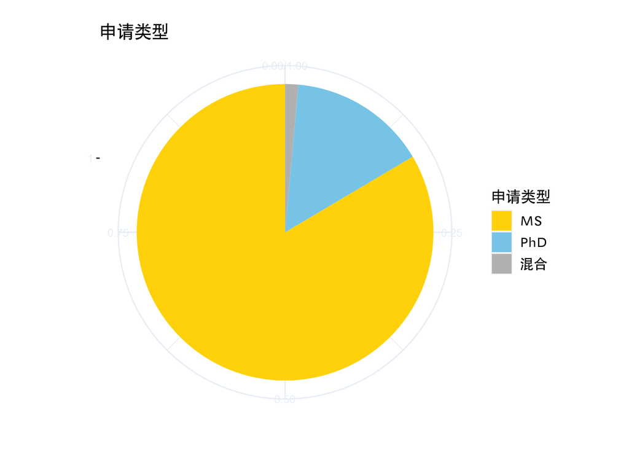

```r
## 绘制饼状图
(piechart2 <- ggplot(descriptive, aes(x = factor(1), fill = factor(type))) +
    geom_bar(position = "fill", width = 1) +
    scale_fill_manual("申请类型", values = c("gold","skyblue","grey")) +
    coord_polar(theta = "y") +
    labs(x = "", y = "", title = "\n申请类型") +
    plot_theme_pie)
```

下面，绘制出硬件条件与申请学位的矩阵图。矩阵的每个元素代表对应学位的所有申请者中，提到自己具备对应硬件条件的人数比例。以（1,1）元素为例，表示硕士申请者中，提到自己有过交换出国经历的比例为2.8%。注意：利用R包data.table和reshape能够简化矩阵计算；横纵坐标各水平的先后顺序与下图保持一致。从图中你能得到什么结论？

```r
# library(reshape)
## 预处理
descriptive$first <- abs(descriptive$first)
descriptive$sci <- abs(descriptive$sci)

## 录取情况与硬件条件
extra_offertype <- descriptive[, c("rl", "intern", "research", "paper",
                                   "first", "sci", "exchange", "type")]
tab1 <- table(extra_offertype$type)
extra_offertype <- melt(extra_offertype, id = "type")      # 短表变长表
count <- subset(extra_offertype, extra_offertype$value == 1)

tab2 <- table(count$type, count$variable)                  # 申请硕博拥有某硬件条件的情况
count_plot <- melt(rbind(tab2[1, ]/tab1[1], tab2[2, ]/tab1[2],  tab2[3, ]/tab1[3]))  # 学位×硬件条件
colnames(count_plot)[1:2] <- c("Var1", "Var2")
count_plot$Var1 <- factor(count_plot$Var1, levels = c(1, 2, 3),        # 调整变量因子水平
                       labels = c("MS", "PhD", "混合"))
count_plot$Var2 <- factor(count_plot$Var2, levels = c("research","paper","first",
                                                  "sci","rl","intern","exchange"),
                           labels = c("科研", "论文", "一作", "SCI论文", "牛推", "实习", "交换"))
```

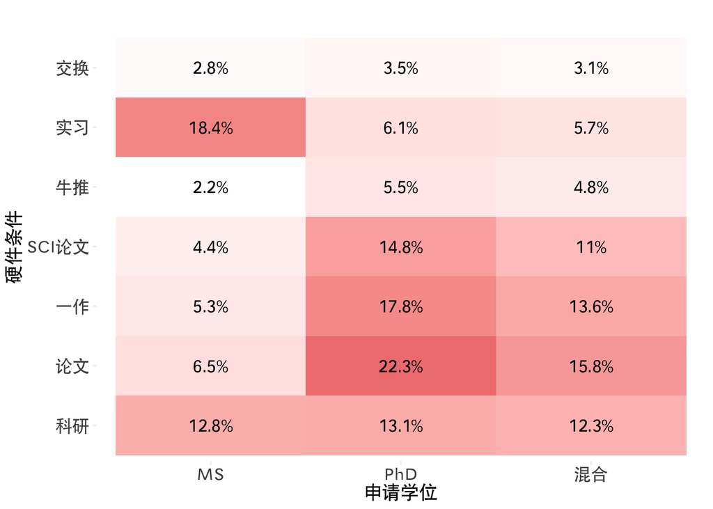

```r
## 绘制硬件条件与申请学位的热力图
(matrix1 <- ggplot(count_plot, aes(x = Var1, y = Var2, fill = value)) + # 画图
    geom_tile(show.legend = F) +
    geom_text(label = paste(round(count_plot$value, 3)*100, "%", sep = ''),
              color = "black", family = "Hei", size = 4.5) +
    scale_fill_gradient("count", low = "white", high = "lightCoral") +
    labs(x = "申请学位", y = "硬件条件", title = "") + plot_theme)
```

#### 申请专业

接着，我们看看热门专业在申请出国留学时的“难度系数”。统计各申请专业（major_apply）出现次数，找出十大热门专业：“CS”,EE“,Stat/Biostat”、“ME”、“MIS”、“CE”、“Material”、“IEOR”、“MFE/Fin/FinMath”和“CivilEng”，依次对应计算机科学电子工程、统计/生统、机械工程、信息系统管理、软件工程、材料、工业工程与运筹学、金融和土木工程。构造新变量 major_apply_new 并入数据，该变量保留10大热门专业，将其余专业归入类型“Other”。随后，计算十大热门专业的录取和拒绝人数，绘制堆积条形图并谈谈你的观点。

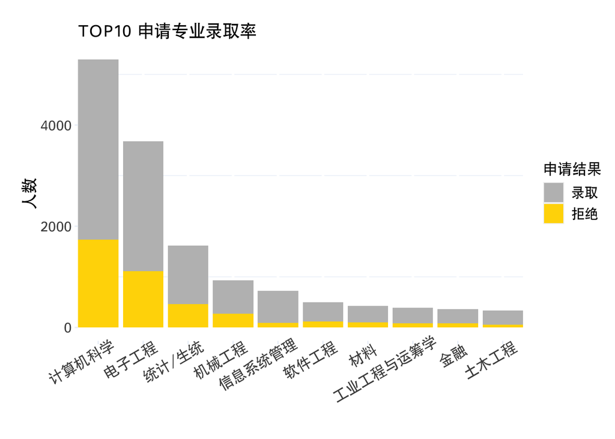

```r
## 计算录取率
ifadmitted <- ifelse(descriptive$offertype == "Admitted",1,0)
admittedPct <- aggregate(ifadmitted,list(descriptive$major_apply),mean)
colnames(admittedPct) <- c("major","admittedpct")

## 选出热门专业
major_ap_top <- as.data.frame(sort(table(descriptive$major_apply),
                                   decreasing = T)[c(1:7, 9:11)])  # 统计申请专业
descriptive$major_apply_new <- ifelse(descriptive$major_apply %in% as.character(major_ap_top$Var1),
                                      descriptive$major_apply, "Other")   # 新变量将冷门专业合并

colnames(major_ap_top) <- c("major","number")                      # 修改列名
top10mj_ap_Pct <- admittedPct[is.element(admittedPct$major, major_ap_top$major), ]
top10mj_ap_Pct <- top10mj_ap_Pct[order(top10mj_ap_Pct$admittedpct, decreasing = T), ]
top10major <- merge(major_ap_top, top10mj_ap_Pct, by = "major",sort = F)  # 合并专业出现次数和录取率
top10major$major<- c("计算机科学", "电子工程", "统计/生统", "机械工程", "信息系统管理", "软件工程",
                     "材料", "工业工程与运筹学", "金融", "土木工程")
top10major_ <- data.frame(major = rep(top10major$major,2),         # 构造data.frame以便画图
                          number = c(top10major$number * top10major$admittedpct,
                                     top10major$number * (1-top10major$admittedpct)),
                          申请结果 = c(rep("录取", 10), rep("拒绝", 10)))
## 画图
(barplot3 <- ggplot(top10major_, aes(x = major, y = number, fill = 申请结果)) +
    geom_bar(show.legend = T, stat = 'identity', position = 'stack') +
    labs(x = "", y = "\n人数", title = "\nTOP10 申请专业录取率") +
    scale_x_discrete(expand=c(0, 0), limits = top10major_$major[1:10]) +
    scale_fill_manual("申请结果", values = c("grey", "gold")) +    # 按照申请结果填色
    theme(axis.text.x = element_text(angle = 30, hjust = 0.8)) +
    plot_theme)
```

结论：计算机科学、统计/生统等专业录取率较低，信息系统管理、土木工程等专业录取率较高。热门专业竞争激烈，录取率低。

#### 学校-专业录取率

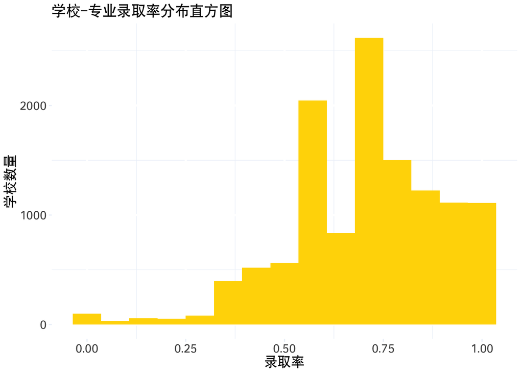

```r
library(dplyr)

descriptive <- na.omit(descriptive)  # 删去缺失值，剩余12442条记录
## 抽取训练集
set.seed(123)    # 随机数种子
nsample <- sample(x = dim(descriptive)[1], size = dim(descriptive)[1]/5, replace = F)
descriptive_train <- descriptive[-nsample, ]         # 划分出训练集，9954条记录


## 以下操作基于训练集
## 首先选出10个热门申请专业，100所热门学校
top10majorapply <- names(sort(table(descriptive_train$major_apply), decreasing = T)[c(1:7, 9:11)])  # 第8为原始Other

Top100college <- names(sort(table(descriptive_train$College_apply_new), decreasing = T)[1:100])    # 热门百所大学
descriptive$College_apply_new[which(!descriptive$College_apply_new %in% Top100college)] = "Others"  # 其余大学命名为 Others
descriptive_train <- descriptive[-nsample, ]         # 划分出训练集，9954条记录

Top100college <- c(Top100college, "Others")

## 预处理：估计训练集录取率
admittedPct = NULL
LengthCollege = NULL
for(i in 1:length(Top100college)){  # 对每一所学校（Top100+Others）
  college1 <- descriptive_train[descriptive_train$College_apply_new == Top100college[i],
                                  c("major_apply", "offertype")]
  # temp1 <- sort(table(college1$major_apply), decreasing = T)
  # temp1 <- names(temp1[temp1 >= 10])                          # 统计各项出现次数
  # majors1 <- ifelse((college1$major_apply %in% top10majorapply) & (college1$major_apply %in% temp1),
                      # college1$major_apply, "Other")          # 出现次数较少的项合并计算录取率
  majors1 <- ifelse((college1$major_apply %in% top10majorapply), college1$major_apply, "Other")
  ifadmitted1 <-  ifelse(college1$offertype == "Admitted", 1, 0)
  admittedPct1 <- aggregate(ifadmitted1, list(majors1),  function(x){mean(x, na.rm = T)} ) # 计算录取率
  if (sum(is.na(admittedPct1)) > 0) {
    cat(Top100college[i], "\t", i, "\n", admittedPct1, "\n")
  }
  LengthCollege[i] <- dim(admittedPct1)[1]                    # 记录出现次数
  colnames(admittedPct1) <- c("major_apply_new", "admittedpct_major_college")
  admittedPct <- rbind(admittedPct, admittedPct1)
}
admittedPct$College_apply_new <- as.factor(unlist(sapply(1:length(Top100college),    # 得到估计的各学校专业录取率
                                                              function(x){rep(Top100college[x], LengthCollege[x])})))


## 得到新变量：学校-专业录取率
descriptive <- merge(descriptive, admittedPct, by = c("College_apply_new", "major_apply_new"), all.x = T)
descriptive <- descriptive[order(descriptive[, "index_origin"]),]   # 保证数据顺序不变

## 测试集中不属于训练集分类中的情况，用其对应的申请学校平均录取率代替
## 计算平均录取率
descriptive_train <- descriptive[-nsample, ]         # 划分出训练集，9954条记录
mean_admitpct_bycollege <- descriptive_train %>% group_by(College_apply_new) %>% summarise(mean_admitpct = mean(admittedpct_major_college))
na_college <- unique(descriptive$College_apply_new[which(is.na(descriptive$admittedpct_major_college))])
mean_admitpct_bycollege <- descriptive_train[which(descriptive_train$College_apply_new %in% na_college),] %>% group_by(College_apply_new) %>% summarise(mean_admitpct = mean(admittedpct_major_college))
colnames(mean_admitpct_bycollege)[2] <- "admittedpct_major_college"


descriptive_sub <- descriptive[which(is.na(descriptive$admittedpct_major_college)),]  # 选择有空值的数据
descriptive_sub$admittedpct_major_college = NULL
descriptive_sub <- merge(descriptive_sub, mean_admitpct_bycollege, by = "College_apply_new", all.x = T)  # 与每个学校的平均录取率合并
descriptive[which(is.na(descriptive$admittedpct_major_college)),] <- descriptive_sub  # 替换原始数据中的空值记录

# for(i in 1:length(Top100college)){
#   admittedpct1 <- admittedPct[admittedPct$Top100_college_apply %in% Top100college[i] & admittedPct$major_apply=="Others", ]
#   if(dim(admittedpct1)[1]!=0){   # 该专业在该学校不属于“冷门专业”（即属于Others）时
#     admittedpct1 <- admittedpct1$admittedpct_major_college
#     descriptive$admittedpct_major_college[(descriptive$Top100_college_apply %in% Top100college[i]) &
#                                              (is.na(descriptive$admittedpct_major_college))] <- admittedpct1
#   }
# }

## 录取率
Admittedpct_major_college <- data.frame(admittedPct = descriptive$admittedpct_major_college)
(histogram1 <- ggplot(Admittedpct_major_college, aes(admittedPct)) +
  geom_histogram(bins =15, fill = "gold") +
  labs(y ="学校数量", x = "录取率", title = "学校-专业录取率分布直方图") +
  plot_theme)
```

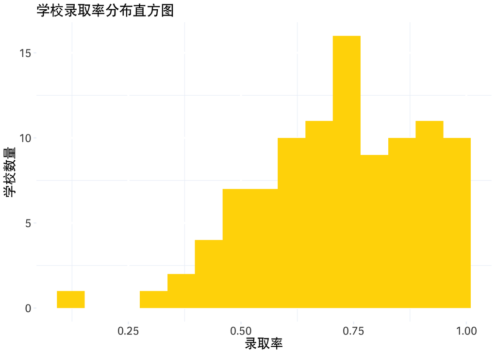

```r
## 只看学校的录取率
mean_admitpct_bycollege_all <- descriptive_train %>% group_by(College_apply_new) %>% summarise(mean_admitpct = mean(admittedpct_major_college))
Admittedpct_college<- data.frame(admittedPct = mean_admitpct_bycollege_all$mean_admitpct)
(histogram1 <- ggplot(Admittedpct_college, aes(admittedPct)) +
  geom_histogram(bins =15, fill = "gold") +
  labs(y ="学校数量", x = "录取率", title = "学校录取率分布直方图") +
  plot_theme)
```

## 5. 建模分析

### 构造逻辑回归模型

```r
set.seed(123)    # 随机数种子
nsample <- sample(x = dim(descriptive)[1], size = dim(descriptive)[1]/5, replace = F)
descriptive_train <- descriptive[-nsample, ]         # 划分出训练集，9954条记录
descriptive_test <- descriptive[nsample, ]
```

以上述方程在训练集数据上建立逻辑回归模型，对模型进行变量选择（使用AIC准则），并对模型结果给出合理的解读。

```r
## [1] "offertype ~ season + type + cross + rl + intern + research + paper + first + sci + exchange + CollegeRankTop50 + gpa_dis + toefl_dis + major_apply_new + admittedpct_major_college"
## 建立逻辑回归模型
myglm0 <- glm(formula = as.factor(offertype) ~ season + type + cross + rl + intern + research + paper + first + sci + exchange + CollegeRankTop50 + gpa_dis + toefl_dis + major_apply_new + admittedpct_major_college, family = binomial(), data = descriptive_train)  # 逻辑回归
myglm <- step(myglm0, trace = F)     # AIC准则逐步回归
summary(myglm)    # 查看回归结果
```

```
##
## Call:
## glm(formula = as.factor(offertype) ~ season + intern + paper +
##     sci + exchange + CollegeRankTop50 + gpa_dis + toefl_dis +
##     admittedpct_major_college, family = binomial(), data = descriptive_train)
##
## Deviance Residuals:
##     Min       1Q   Median       3Q      Max
## -2.4686  -0.7716  -0.5045   0.8567   2.4858
##
## Coefficients:
##                           Estimate Std. Error z value Pr(>|z|)
## (Intercept)                3.49022    0.13278  26.285  < 2e-16 ***
## seasonSpring              -0.49205    0.18579  -2.648  0.00809 **
## intern                     0.17797    0.06494   2.741  0.00613 **
## paper                     -0.26820    0.09259  -2.897  0.00377 **
## sci                       -0.22740    0.11160  -2.038  0.04158 *
## exchange                  -0.86591    0.16708  -5.183 2.19e-07 ***
## CollegeRankTop50Top50      0.12127    0.05432   2.233  0.02558 *
## gpa_dis3.4~3.55           -0.09473    0.06533  -1.450  0.14702
## gpa_dis3.55~3.7           -0.42474    0.07000  -6.067 1.30e-09 ***
## gpa_dis>3.7               -0.65404    0.07776  -8.411  < 2e-16 ***
## toefl_dis98~102           -0.10982    0.07011  -1.566  0.11725
## toefl_dis102~106          -0.22033    0.07149  -3.082  0.00206 **
## toefl_dis>106             -0.42965    0.07868  -5.461 4.73e-08 ***
## admittedpct_major_college -5.84324    0.16062 -36.378  < 2e-16 ***
## ---
## Signif. codes:  0 '***' 0.001 '**' 0.01 '*' 0.05 '.' 0.1 ' ' 1
##
## (Dispersion parameter for binomial family taken to be 1)
##
##     Null deviance: 11884.2  on 9800  degrees of freedom
## Residual deviance:  9868.5  on 9787  degrees of freedom
## AIC: 9896.5
##
## Number of Fisher Scoring iterations: 4
```

### 逐步回归与ROC曲线

用逐步回归后的模型对测试集的申请结果进行预测，并利用R包pROC绘制出ROC曲线图，根据曲线对模型进行评价。

```r
library(pROC)
library(caret)
# 进行预测并绘制ROC曲线
pred <- predict(myglm, descriptive_test, type="response")
roc_glm <- roc(descriptive_test$offertype, pred)
```

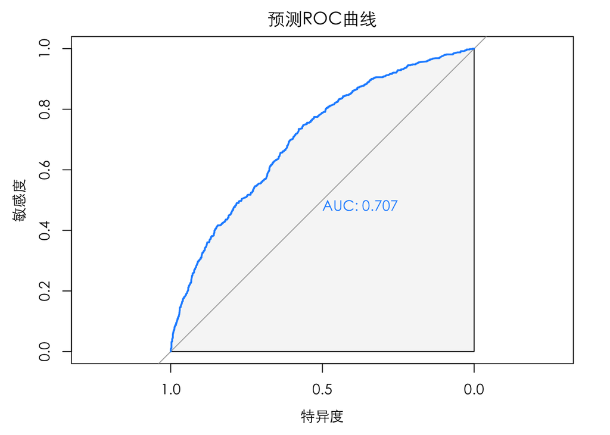

```r
# 绘制ROC曲线
par(family='STXihei')
plot(roc_glm, col = "dodgerblue", print.auc=TRUE,
         auc.polygon=TRUE, auc.polygon.col="#f6f6f6", main = "预测ROC曲线", xlim = c(1,0),
     xlab = "特异度",ylab = "敏感度")
```